# Project 3: Poisonous mushrooms

In this project, you'll investigate properties of mushrooms. This classic dataset contains over 8000 observations, where each mushroom is described by a variety of features like color, odor, etc., and the target variable is an indicator for whether the mushroom is poisonous. Since all the observations are categorical, I've binarized the feature space. Look at the feature_names below to see all 126 binary names.

You'll start by running PCA to reduce the dimensionality from 126 down to 2 so that you can easily visualize the data. In general, PCA is very useful for visualization (though sklearn.manifold.tsne is known to produce better visualizations). Recall that PCA is a linear transformation. The 1st projected dimension is the linear combination of all 126 original features that captures as much of the variance in the data as possible. The 2nd projected dimension is the linear combination of all 126 original features that captures as much of the remaining variance as possible. The idea of dense low dimensional representations is crucial to machine learning!

Once you've projected the data to 2 dimensions, you'll experiment with clustering using KMeans and density estimation with Gaussian Mixture Models. Finally, you'll train a classifier by fitting a GMM for the positive class and a GMM for the negative class, and perform inference by comparing the probabilities output by each model.

As always, you're welcome to work on the project in groups and discuss ideas on the course wall, but please prepare your own write-up and write your own code.

```python
%matplotlib inline

import numpy as np
import matplotlib.pyplot as plt
from sklearn import metrics
from sklearn.decomposition import PCA
from sklearn.cluster import KMeans
from sklearn.mixture import GMM
from matplotlib.colors import LogNorm
```

Load feature names.

```python
feature_names = []
with open('./data/mushroom.map') as fmap:
    for line in fmap:
        [index, name, junk] = line.split()
        feature_names.append(name)

print('Loaded feature names: {0}'.format(len(feature_names)))
```

```
Loaded feature names: 126
```

Load data. The data is sparse in the input file, but there aren't too many features, so we'll use a dense representation, which is supported by all sklearn objects.

```python
X, Y = [], []

with open('./data/mushroom.data') as fdata:
    for line in fdata:
        items = line.split()
        Y.append(int(items.pop(0)))
        x = np.zeros(len(feature_names))
        for item in items:
            feature = int(item.split(':')[0])
            x[feature] = 1
        X.append(x)

# Convert these lists to numpy arrays.
X = np.array(X)
Y = np.array(Y)

# Split into train and test data.
train_data, train_labels = X[:7000], Y[:7000]
test_data, test_labels = X[7000:], Y[7000:]

# Check that the shapes look right.
print(train_data.shape)
print(test_data.shape)
```

```
(7000, 126)
(1124, 126)
```

(1) Run Principal Components Analysis on the data. Show what fraction of the total variance in the training data is explained by the first k principal components, for k in [1, 50].

```python
from sklearn.preprocessing import StandardScaler

def calc_pca(data, n, standardize):
    """
    Calc Principal component analysis
    """
    # standardize the data?
    if (standardize):
        data = StandardScaler().fit_transform(data)

    pca = PCA(n_components = n)
    xd = pca.fit_transform(data)

    return pca,xd

def calc_explained_variance_of_pca_for_n_components(data, n, standardize=True):
    """
    Calc explained variance ratio for n_components
    """
    # Calc pca and explained variance for 1..n
    results = {}
    for k in range(1,n+1):
        pca,xd = calc_pca(data,k,standardize)
        results[k]=np.sum(100*pca.explained_variance_ratio_)

    return results
```

Lets plot these results so we can see how the explained variance behaves, vs. n_components

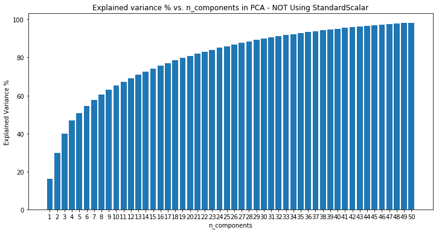

```python
results = calc_explained_variance_of_pca_for_n_components(train_data, 50, False)

fig_size = plt.rcParams["figure.figsize"]
fig_size[1] = 6
fig_size[0] = 12
plt.rcParams["figure.figsize"] = fig_size

fig,ax = plt.subplots()
plt.bar(range(len(results)), list(results.values()), align='center')
plt.xticks(range(len(results)), list(results.keys()))
plt.title("Explained variance % vs. n_components in PCA - NOT Using StandardScalar")
plt.xlabel("n_components")
plt.ylabel("Explained Variance %")
ax.set_facecolor('white')
plt.show()
```

(2) PCA can be very useful for visualizing data. Project the training data down to 2 dimensions and plot it. Show the positive (poisonous) cases in blue and the negative (non-poisonous) in red. Here's a reference for plotting: http://matplotlib.org/users/pyplot_tutorial.html

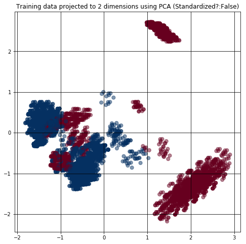

```python
def vizualize_pca(xd,labels,n,standardize=True):
    """
    Vizualize PCA for n dimension
    """
    fig_size[1] = 8
    fig_size[0] = 8
    plt.rcParams["figure.figsize"] = fig_size
    fig,ax = plt.subplots()
    plt.scatter(x=xd[:,0],y=xd[:,1], c=labels, cmap='RdBu_r', s=50, alpha=0.5)
    plt.title("Training data projected to {0} dimensions using PCA (Standardized?:{1})".format(n,standardize))
    plt.grid(b=True, which='both', color='0', linestyle='-')
    ax.set_facecolor('white')
    plt.show()


# Create pca for 2 components and visualize
n=2
pca, xd = calc_pca(train_data,n,False)
vizualize_pca(xd,train_labels,n,False)
```

(3) Run KMeans with [1,16] clusters over the 2d projected data. Mark each centroid cluster and plot a circle that goes through the most distant point assigned to each cluster.

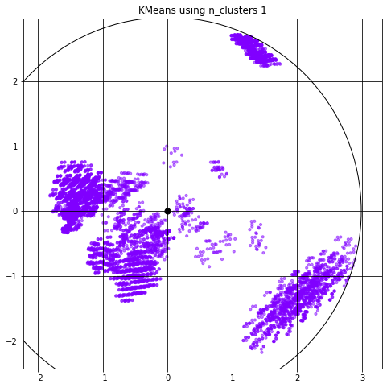

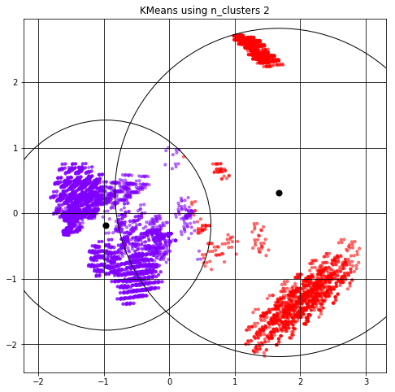

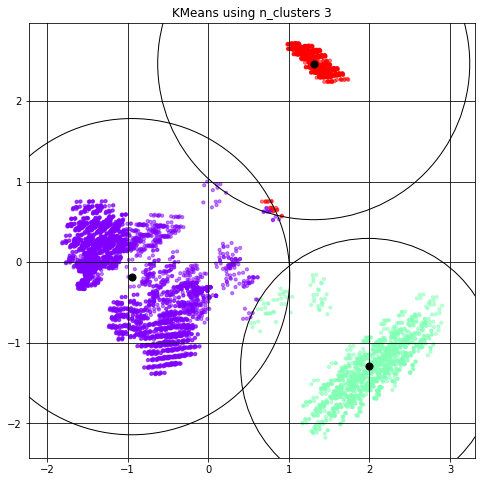

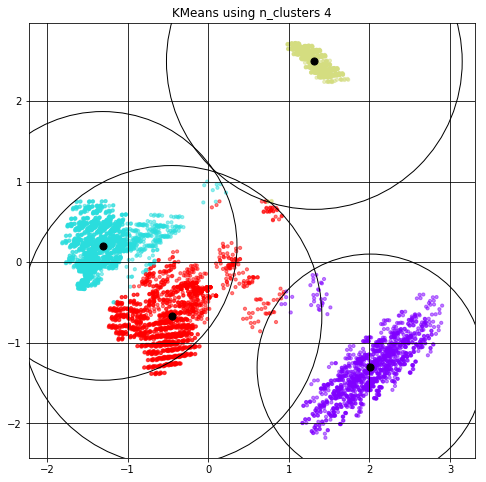

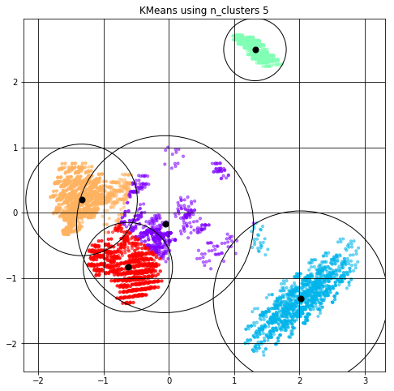

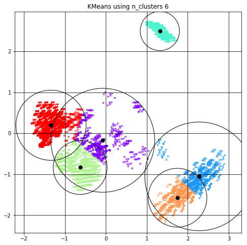

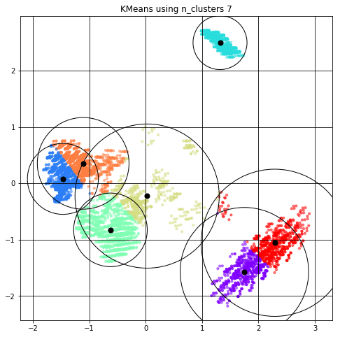

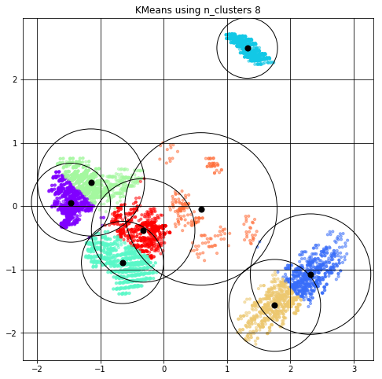

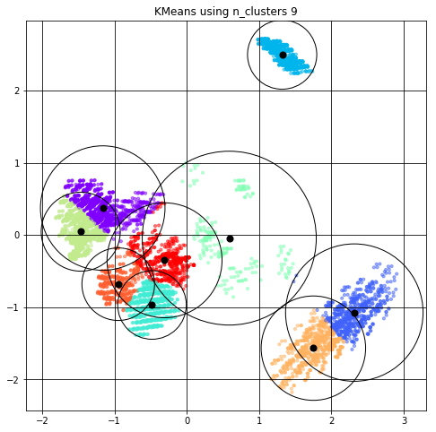

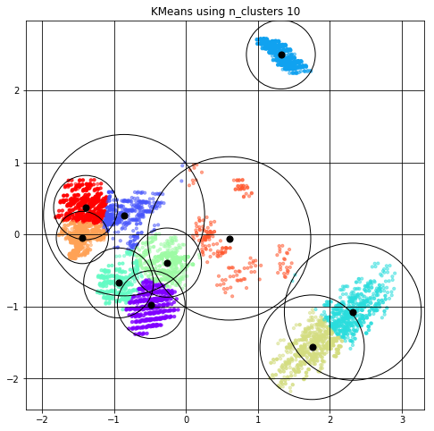

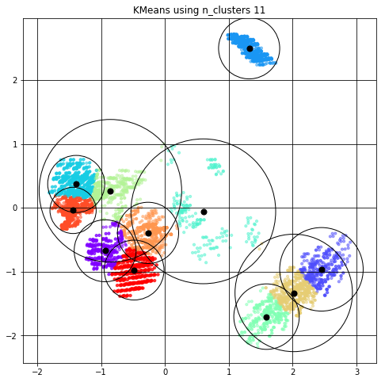

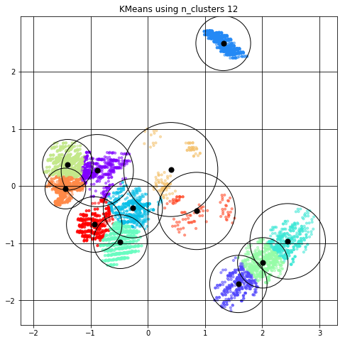

[4 more figures not shown]

```python
import itertools
import math
import pandas as pd

def calc_euclidean_distance(pointA,pointB):
    """
    Define a (euclidean) distance function between two points
    """
    x=((1.0*pointA[0])-(1.0*pointB[0]))**2
    y=((1.0*pointA[1])-(1.0*pointB[1]))**2
    return math.sqrt(x+y)


def create_circle(x,y,r,ax):
    """
    Create a circle and properties
    """
    color = "black"

    circle=plt.Circle((x,y),radius=r)
    circle.set_facecolor("None")
    circle.set_edgecolor(color)
    circle.set_clip_box(ax.bbox)
    ax.add_artist(circle)


def plot_circles(xd, cluster_centers, y_kmeans, ax):
    """
    Plot circles based on max distance from kmeans cluster center using euclidean distance
    Note: See Jacob Vanderplas: Python Data Science Handbook for a more concise implementation
          which uses scipy.spatial.distance (cdist)
    """
    # Determine centers for each kmeans cluster ( and create tuple(x,y) )
    l = [(cluster_centers[x][0],cluster_centers[x][1]) for x in y_kmeans]
    # Determine estimate ( as a tuple(x,y) )
    l2 = [(x[0],x[1]) for x in xd]

    # Calc distances
    distances = [ (x[0],calc_euclidean_distance(x[1],x[2])) for x in zip(y_kmeans,l,l2)]

    # Group distances by cluster and extract max per cluster
    # Note, unless distances are sorted, itertools does not return the correct value!
    kmeans_max_distances = [ max(v[1]) for v in itertools.groupby(sorted(distances), key=lambda x: x[0])]

    # Plot circles for each cluster ( raidus = max_distance * scaling_factor ), and add a centre point in black
    for c,ct in enumerate(cluster_centers):
        create_circle(ct[0],ct[1],kmeans_max_distances[c][1], ax)
        plt.scatter(ct[0],ct[1],s=50,c="black",alpha=1)


def create_kmeans_and_plot(xd,n):
    """
    Create kmeans, plot clusters and draw circles with radius = max euclidean distance
    """

    # Create 'n' clusters using KMeans and fit to xd projected data
    kmeans = KMeans(n_clusters=n)
    kmeans.fit(xd)

    # Predict which clusters each x2d point is associated with
    y_kmeans = kmeans.predict(xd)

    fig,ax = plt.subplots()

    # Plot scatter, coloring based on cluster k
    plt.scatter(xd[:, 0], xd[:, 1], c=y_kmeans, s=10, cmap='rainbow', alpha=0.5)
    plt.title('KMeans using n_clusters {0}'.format(n))
    plt.grid(b=True, which='both', color='0', linestyle='-')
    ax.set_facecolor('white')
    ax.axis('equal')

    # Now add circles and centre point for each cluster
    plot_circles(xd,kmeans.cluster_centers_,y_kmeans,ax)

    plt.show()


# Set fig size
fig_size[1] = 8
fig_size[0] = 8
plt.rcParams["figure.figsize"] = fig_size

x_max=16

# Plot kmeans clusters ( 1..x_max*y_max ~ 16 )
# Note: doing this for standardized x2d data only ( but could be done for original data as well )
for x in range(1,x_max+1):
        create_kmeans_and_plot(xd,x)
```

It is important to note, KMeans cluster models MUST be circular, it has no way to account for elliptical or oblong clusters.

(4) Fit a Gaussian Mixture Model for the positive examples in your 2d projected data. Plot the estimated density contours as shown here: http://scikit-learn.org/stable/auto_examples/mixture/plot_gmm_pdf.html#example-mixture-plot-gmm-pdf-py. Vary the number of mixture components from 1-4 and the covariance matrix type ('spherical', 'diag', 'tied', 'full').

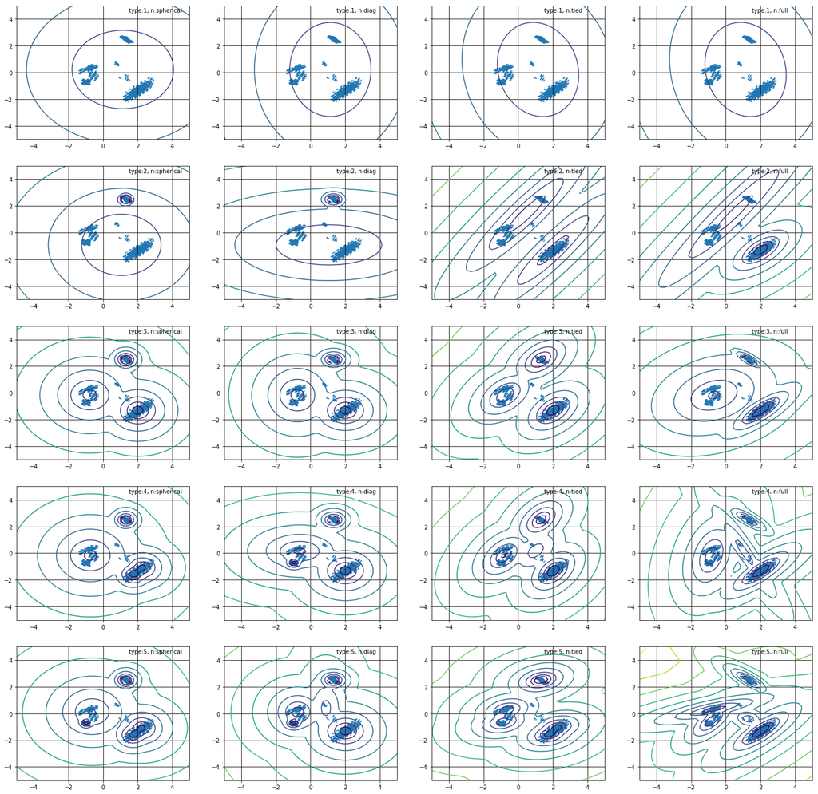

```python
import numpy as np
import matplotlib.pyplot as plt
from matplotlib.colors import LogNorm
from sklearn import mixture


def get_axis_limits(ax, scale=.9, offsets=(0,0)):
    """
    Get axis limits - used for annotation placement
    Taken from https://stackoverflow.com/questions/24125058/add-label-to-subplot-in-matplotlib
    """
    return ((ax.get_xlim()[1]*scale)+offsets[0]), ((ax.get_ylim()[1]*scale)+offsets[1])


def plot_gmm_density_contours(x_data,n,ct,ax):
    """
    Fit and plot a Gaussian Mixture Model ( with n ~ components and ct ~ covariance type )
    Derived from http://scikit-learn.org/stable/auto_examples/mixture/plot_gmm_pdf.html#example-mixture-plot-gmm-pdf-py
    """
    # fit a Gaussian Mixture Model with two components
    clf = mixture.GaussianMixture(n_components=n, covariance_type=ct)
    clf.fit(x_data)

    # display predicted scores by the model as a contour plot
    x = np.linspace(-5., 5.)
    y = np.linspace(-5., 5.)
    X, Y = np.meshgrid(x, y)
    XX = np.array([X.ravel(), Y.ravel()]).T
    Z = -clf.score_samples(XX)
    Z = Z.reshape(X.shape)

    CS = ax.contour(X, Y, Z, norm=LogNorm(vmin=1.0, vmax=1000.0),
                     levels=np.logspace(0, 3, 10))
    #CB = ax.colorbar(CS, shrink=0.8, extend='both')

    # extract coordinates and plot scatter
    x,y = zip(*x_data)
    ax.set_facecolor('white')
    ax.scatter(x, y, .8)
    ax.grid(b=True, which='both', color='0', linestyle='-')
    ax.annotate('type:{0}, n:{1}'.format(n,ct), xy=get_axis_limits(ax,0.9,(-3,0)))


# Prepare positive only labels
xd_filtered = [x for x,y in zip(xd, train_labels) if y==1 ]

# configure figure for 20 plots (5x4)
fig,ax = plt.subplots(5,4)
fig.set_figheight(25)
fig.set_figwidth(25)

# Iterate over permutations of covariance type and n components
for y,ct in enumerate(['spherical', 'diag', 'tied', 'full']):
    for x,n in enumerate(range(1,6)):
        plot_gmm_density_contours(xd_filtered,n,ct,ax[x,y])
```

As we can see by these GMM contour maps, the gaussian mixed model is not constrained as is the kmeans model and it is able to change the shape of the clusters making them eliptical to match the shapes of the clusters.

The type of covariance used affects the shape of the cluster created and allowing for "full" covariance allows the model to create the eliptical clusters.

We also see as the number of components increases, the GMM is better able to match the clustering within the input data.

(5) Fit two 4-component full covariance GMMs, one for the positive examples and one for the negative examples in your 2d projected data. Predict the test examples by choosing the label for which the model gives a larger probability (use GMM.score). What is the accuracy?

```python
def calc_accuracy(xd, xd_test, test_labels,n_components, covariance_type="full"):
    """
    Calculate the accuracy of xd_test vs. xd
    """
    # Prepare positive and not-positive xd based on labels
    xd_positive = [x for x,y in zip(xd, train_labels) if y==1 ]
    xd_not_positive = [x for x,y in zip(xd, train_labels) if y!=1 ]

    # fit a Gaussian Mixture Model with n components
    clf_p = mixture.GaussianMixture(n_components=n_components, covariance_type=covariance_type)
    clf_p.fit(xd_positive)

    # predict and calc likelihood
    y_test_positive = clf_p.predict(xd_test)
    z_p=clf_p.score_samples(xd_test)
    likelihood_p = np.exp(z_p)

    number_of_parameters = 2*(clf_p.means_.size + clf_p.covariances_.size)

    # fit a Gaussian Mixture Model with n components
    clf_np = mixture.GaussianMixture(n_components=n_components, covariance_type=covariance_type)
    clf_np.fit(xd_not_positive)
    clf_np.fit(xd_not_positive)

    # predict and calc likelihood
    y_test_not_positive = clf_np.predict(xd_test)
    z_np=clf_np.score_samples(xd_test)
    likelihood_np = np.exp(z_np)

    # Determine array items predicted correctly vs. test labels
    predicted=((likelihood_p>likelihood_np)==test_labels)

    # Accuracy = (Σ True positive + Σ True negative) / Σ Total population
    # https://en.wikipedia.org/wiki/Precision_and_recall

    accuracy = np.count_nonzero(predicted)/np.size(predicted)

    return 100*accuracy, number_of_parameters
```

```python
n=2
pca, xd = calc_pca(train_data,n,False)

#calc x2d for test_data
# 4 components using the full covariance matrix
xd_test = pca.transform(test_data)

acc,number_of_parameters = calc_accuracy(xd, xd_test, test_labels,4,"full")

# Show final results
print("accuracy: {0:.4f} %".format(acc))
print("number of parameters: {0}".format(number_of_parameters))
```

```
accuracy: 95.0178 %
number of parameters: 48
```

(6) Ideally, we'd like a model that gives the best accuracy with the fewest parameters. Run a series of experiments to find the model that gives the best accuracy with no more than 50 parameters. For example, with 3 PCA components and 2-component diagonal covariance GMMs, you'd have:

( (3 mean vector + 3 covariance matrix) x 2 components ) x 2 classes = 24 parameters

You should vary the number of PCA components, the number of GMM components, and the covariance type.

```python
import sys
from ipywidgets import FloatProgress
from IPython.display import display

class DetermineNumberOfParametersFactory(object):
    """
    Factory class to determine the number of parameters based on the covariance matrix type
    """
    def calc(self, covariance_type, pca_n_components, gmm_n_components, n_classes):
        method = getattr(self, "_" + covariance_type, lambda: "Invalid covariance type")
        return method(pca_n_components, gmm_n_components, n_classes)

    def _spherical(self,pca_n_components, gmm_n_components, n_classes):
        """
        spherical ~ each component has its own single variance
        """
        n_variances_per_gaussian = 1
        n_means_per_gaussian = pca_n_components
        return (n_means_per_gaussian + n_variances_per_gaussian ) * gmm_n_components * n_classes

    def _diag(self,pca_n_components, gmm_n_components, n_classes):
        """
        diag ~ diagonal retains values, all other entries are zero
        """
        n_variances_per_gaussian = pca_n_components # (D ~ diagonal only)
        n_means_per_gaussian = pca_n_components
        return (n_means_per_gaussian + n_variances_per_gaussian ) * gmm_n_components * n_classes

    def _tied(self,pca_n_components, gmm_n_components, n_classes):
        """
        tied ~ all components share the same general covariance matrix  BUT have own # means per component
        """
        n_variances_per_gmm = pca_n_components**2 # (DxD matrix)
        n_means_per_gaussian = pca_n_components
        return (n_means_per_gaussian * gmm_n_components + n_variances_per_gmm) * 1 * n_classes

    def _full(self,pca_n_components, gmm_n_components, n_classes):
        """
        full ~ each component has its own general covariance matrix
        """
        n_variances_per_gmm = pca_n_components**2 # (DxD matrix)
        n_means_per_gaussian = pca_n_components
        return (n_means_per_gaussian + n_variances_per_gmm) * gmm_n_components * n_classes


def search(max_number_of_parameters, train_data,test_data,test_labels, trace=True):
    """
    Search for best accuracy using least number of parameters
    """
    f=DetermineNumberOfParametersFactory()
    n_classes=2
    best_result = 0
    best_number_of_parameters = math.inf

    p = FloatProgress(min=0, max=max_number_of_parameters*max_number_of_parameters*4,description="Running")
    display(p)

    # Nested loops to iterate over # pca components, # gmm components and covariance types
    for pca_n_components in range(1,max_number_of_parameters):

        # train model and create x2d matrix
        pca, xd = calc_pca(train_data,pca_n_components,False)
        xd_test = pca.transform(test_data)

        for gmm_n_components in range(1,max_number_of_parameters):

            for covariance_type in ['spherical', 'diag', 'tied', 'full']:

                # progress tracker
                p.value +=1

                # calc # of parameters created by parameter combination (based on covariance matrix type)
                number_of_parameters = f.calc(covariance_type,pca_n_components,gmm_n_components, n_classes)

                # if < max_number, proceed and calc accuracy
                if (number_of_parameters < max_number_of_parameters):
                    result, pc = calc_accuracy(xd,xd_test,test_labels,gmm_n_components, covariance_type)

                    if (number_of_parameters<=max_number_of_parameters):

                        # result better? yes, record it
                        if (result >= best_result):
                            best_result=result
                            best_number_of_parameters=number_of_parameters
                            best_parameters=(covariance_type,pca_n_components,gmm_n_components)

                        if (trace):
                            print("{0}\t{1}\t{2}\t~ {3}\t{4}".format(covariance_type[:4],pca_n_components,gmm_n_components,number_of_parameters,result))
                            sys.stdout.flush()


    return (best_result,best_number_of_parameters,best_parameters)
```

```python
# Lets now run this
best_result,best_number_of_parameters,best_parameters = search(50, train_data,test_data,test_labels,trace=True)
```

```
sphe	1	1	~ 4	84.4306049822064
diag	1	1	~ 4	84.4306049822064
tied	1	1	~ 4	84.4306049822064
full	1	1	~ 4	84.4306049822064
sphe	1	2	~ 8	89.85765124555161
diag	1	2	~ 8	89.85765124555161
tied	1	2	~ 6	88.34519572953737
full	1	2	~ 8	89.85765124555161
sphe	1	3	~ 12	90.65836298932385
diag	1	3	~ 12	90.65836298932385
tied	1	3	~ 8	92.17081850533808
full	1	3	~ 12	90.48042704626334
sphe	1	4	~ 16	91.37010676156584
diag	1	4	~ 16	91.37010676156584
tied	1	4	~ 10	91.81494661921708
full	1	4	~ 16	90.48042704626334
sphe	1	5	~ 20	91.37010676156584
diag	1	5	~ 20	91.28113879003558
tied	1	5	~ 12	91.28113879003558
full	1	5	~ 20	91.10320284697508
sphe	1	6	~ 24	90.92526690391459
diag	1	6	~ 24	90.83629893238434
tied	1	6	~ 14	91.28113879003558
full	1	6	~ 24	91.10320284697508
sphe	1	7	~ 28	91.45907473309609
diag	1	7	~ 28	91.10320284697508
tied	1	7	~ 16	91.28113879003558
full	1	7	~ 28	90.92526690391459
sphe	1	8	~ 32	90.92526690391459
diag	1	8	~ 32	91.01423487544484
tied	1	8	~ 18	91.28113879003558
full	1	8	~ 32	91.45907473309609
sphe	1	9	~ 36	91.19217081850533
diag	1	9	~ 36	91.37010676156584
tied	1	9	~ 20	91.01423487544484
full	1	9	~ 36	91.45907473309609
sphe	1	10	~ 40	91.45907473309609
diag	1	10	~ 40	91.45907473309609
tied	1	10	~ 22	91.28113879003558
full	1	10	~ 40	91.37010676156584
```

[output cut: 99 more lines]

```
diag	11	1	~ 44	91.28113879003558
sphe	11	2	~ 48	89.5017793594306
sphe	12	1	~ 26	87.72241992882563
diag	12	1	~ 48	91.37010676156584
sphe	13	1	~ 28	87.81138790035587
sphe	14	1	~ 30	87.81138790035587
sphe	15	1	~ 32	87.81138790035587
sphe	16	1	~ 34	87.81138790035587
sphe	17	1	~ 36	87.81138790035587
sphe	18	1	~ 38	87.81138790035587
sphe	19	1	~ 40	87.81138790035587
sphe	20	1	~ 42	87.81138790035587
sphe	21	1	~ 44	87.81138790035587
sphe	22	1	~ 46	87.81138790035587
sphe	23	1	~ 48	87.72241992882563
```

```python
print('Best result: {0}, best number of parameters: {1} using parameters: {2}'.format(best_result,best_number_of_parameters,str(best_parameters)))
```

```
Best result: 97.33096085409252, best number of parameters: 48 using parameters: ('spherical', 7, 3)
```

As we can see from the results trace that there are a number of permutations of parameters that score > 94% accuracy. It would be interesting to repeat the exercise using AIC and BIC to see if the results are significantly different.

I also saw another student used the size of the matrices to calculate the # of parameters, however this is incredibly slow as we need to fit every set of data, so I opted to keep my method of calculating the # parameters.